# Attendance Time and Intercolony Movements

Author

Eleanor

## Intro

My goal here is to create one dataframe that I can use to calculate both colony attendance time (and therefore colony preference) and inter-colony movements. My two problems are 1) how do we decide when a bird “counts” as being in attendance at a colony and 2) what counts as an inter-colony movement?

The main source of the problem is the overlap between Great Island’s northeast facing antenna and Gull Island’s south-facing antenna:

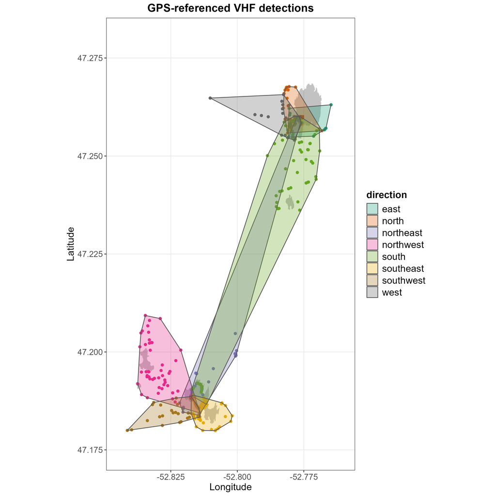

There is a large area of ocean covered by both antennas, but there are also areas of both islands that are covered by both of these antennas, but none of the other 6 antennas. In the past I have written code where a bird was required to be detected on multiple antennas (per receiver) to be considered on an island. This is nicely conservative, because areas of overlap between antennas tend to be mostly land area. However, there are large land areas that are only covered by one antenna per receiver (e.g., the southeast half of Great Island), and I don’t want to exclude time that birds spend in those areas from their colony attendance totals. Here are a couple of examples:

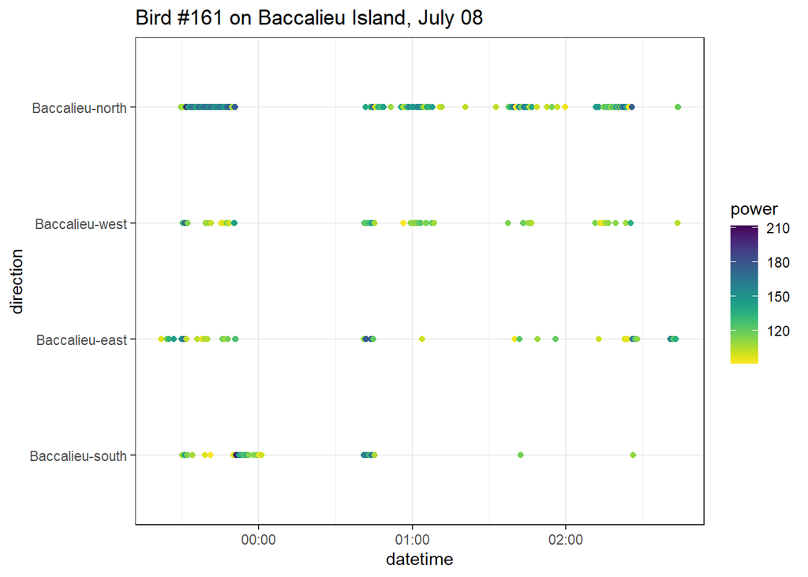

Here, the bird goes in and out of range several times in the night. None of these disappearances are long enough that I think the bird is really leaving the area. If we count just the minutes (1 minute = 1 scan cycle) where the bird was detected, we get an attendance time of 101 minutes. If we count the entire period between the night’s last detection and the night’s first detections, we get an attendance time of 200 minutes. I would rather keep the larger time, because I think those gaps probably still reflect colony attendance behaviour.

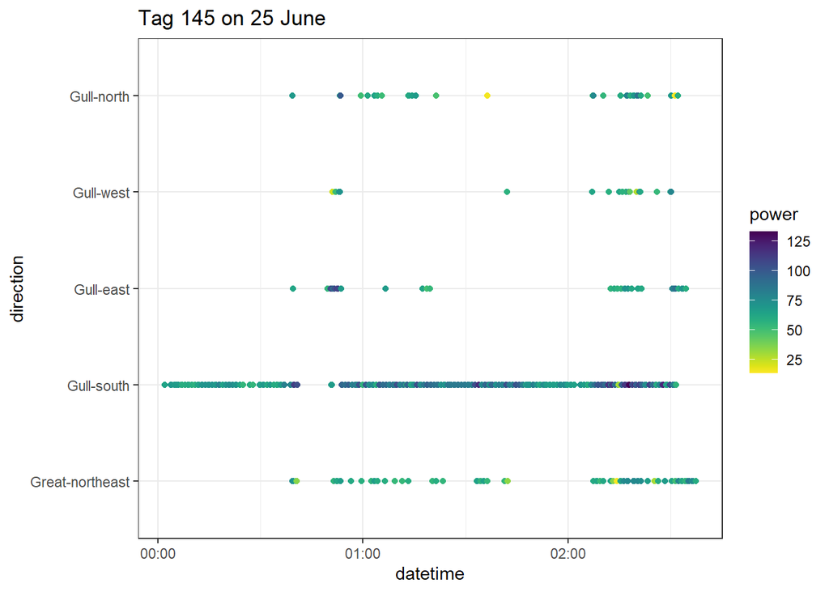

Here, we have big chunks of time where the bird is only detected on the south-facing antenna on Gull Island. If I was using the two-antenna criteria, we would not count the bird as being on any island during these times (and we wouldn’t count any inter-colony movements within this night). I think I do want to count the periods where it is only on the south-facing antenna as colony attendance time: it is obviously in the area, and when it comes to the behavioural decision to leave the foraging grounds and come in close to the colonies, being near but not on the colonies probably still has social and developmental implications.

We take this movement track and group the detections into one-minute bins, then assign each minute to a colony based on two steps: first, which receiver had the most unique antennas represented in that minute (e.g., if you show up on 2 Gull antennas but only 1 Great antenna, you are on Gull), and second, when the number of antennas is equal, which receiver recorded the most transmission power. In that case, we end up with:

```
# A tibble: 2 × 2
  island time
  <chr>  <drtn>
1 Great    60 secs
2 Gull   9180 secs
```

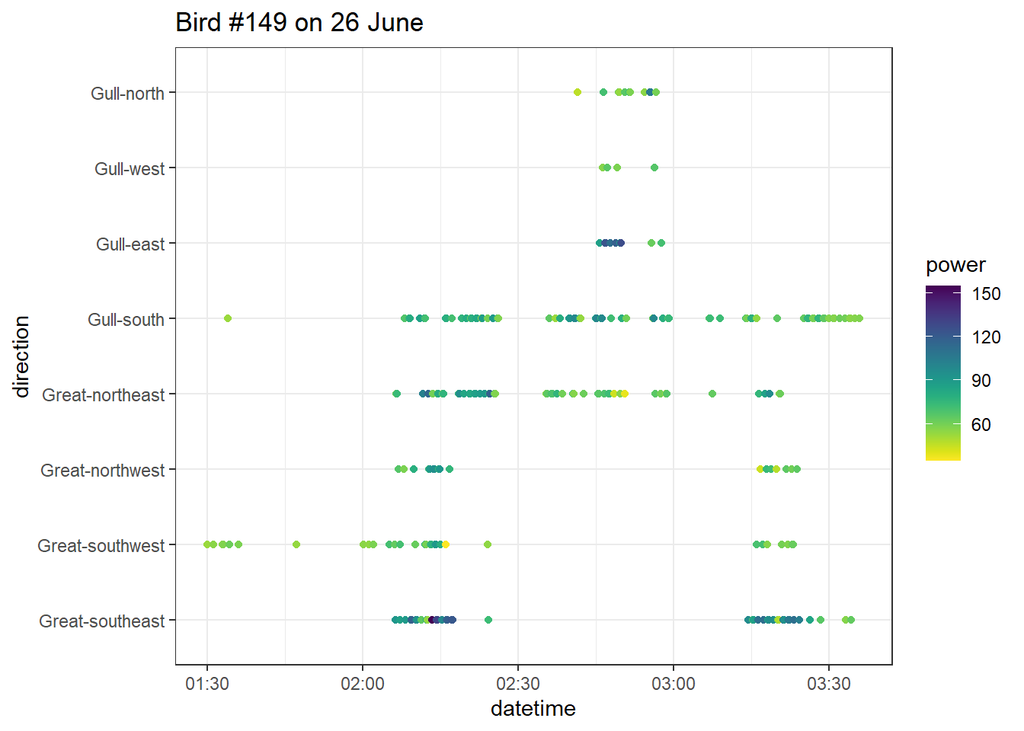

My strategy recently has been to be very inclusive of attendance time, which has the effect of being very liberal in counting inter-colony movements. I’ll show my most recent approach, then we can go through a couple of attempts to be more conservative with inter-colony movements without cutting out too much attendance time. I would like to use a single pipeline to calculate both attendance time and inter-colony movements, though I’m not entirely opposed to analyzing those two behaviours separately.

Note all these analyses will only include 2025 data and none from 2024.

## Approach One: One Minute bins, antenna THEN power priority

This approach relies on a “segmenter” pipeline. First, we group detections into one-minute bins. Then we group them by bin, tag ID, and island. Then we calculate the number of unique antennas per receiver present in each group. We also calculate the total transmission power received by each receiver across all antennas in each minute. We then assign each bird-minute (each group) to an island via two conditional (case_when()) functions:

The first (1st priority) assigns to island based on antenna number. The island which is represented by the most unique antennas in a group ‘wins.’ So if a bird is detected on two Great Island antennas and one Gull Island antennas within a given minute, that minute gets assigned to Great Island.

In cases (and only in cases) where the number of antennas per receiver is equal within a group, we then assign the group based on the total transmission power.

We exclude three individual bird-minutes (each belonging to a different bird) where both the total power received and the number of antennas represented was equal for Great and Gull Island.

```r
visit_segments_loop <- data.frame()

visitors <- prospecting_detections %>%
  filter(nightdate != capture_nightdate) %>%
  group_by(tag_id) %>%
  count() %>%
  dplyr::select(tag_id)

visitors <- as.list(visitors$tag_id) ## Gives a list of every bird that returned at least once

assigned_to_islands <- prospecting_detections %>%  ## Assign to island based first on number of antennas then based on total power received during a scan cycle
  #filter(nightdate != capture_nightdate) %>%
  mutate(bin = binner(datetime, "1 mins")) %>% #Create minute-long bins
  group_by(tag_id, bin, island) %>%
  summarize(n_antennas = length(unique(direction)), total_power = mean(power)) %>%
  pivot_wider(names_from = "island", values_from = c("n_antennas", "total_power"), values_fill = 0) %>% #Show number of unique antennas per receiver in each minute
  rename(gull_antennas = n_antennas_Gull,
         great_antennas = n_antennas_Great,
         gull_power = total_power_Gull,
         great_power = total_power_Great,
         bac_antennas = n_antennas_Baccalieu,
         bac_power = total_power_Baccalieu) %>%
  mutate(area = if_else(bac_antennas > 0, "Baccalieu", "Witless Bay")) %>%
  mutate(island = case_when(area == "Witless Bay" & gull_antennas > great_antennas ~ "Gull",
                            area == "Witless Bay" & great_antennas > gull_antennas ~ "Great",
                            area == "Witless Bay" & gull_antennas == great_antennas ~ "Both",
                            area == "Baccalieu" ~ "Baccalieu")) %>%
  mutate(island = case_when(island == "Both" & gull_power > great_power ~ "Gull",
                            island == "Both" & gull_power < great_power ~ "Great",
                            island != "Both" ~ island,
                            .default = NA)) %>%
  filter(!is.na(island)) %>%
  arrange(desc(bin))
```

```r
for (i in visitors) { #Create iterating segment numbers

groups = list(1)
counter = 1

df <- assigned_to_islands %>%
  filter(tag_id == i) %>%
  mutate(nightdate = nightdater(bin))

  for (n in 2:length(df$tag_id)) {

    if (df$island[n] == df$island[n-1] & as.character(df$nightdate[n]) == as.character(df$nightdate[n-1])) {
      groups <- append(groups,counter)
     # print("same")
     } else {
      counter = counter + 1
      groups <- append(groups,counter)

      #print("dif")
    }

  }

groups <- as.data.frame(groups)

groups <- groups %>%
  pivot_longer(everything())

df <- cbind(df, groups$value) %>%
  dplyr::rename(segment = `...12`)

visit_segments_loop <- rbind(visit_segments_loop, df)
}
```

Now we can look at two results from this dataframe: colony attendance time (and colony preference) and the number of inter-colony movements.

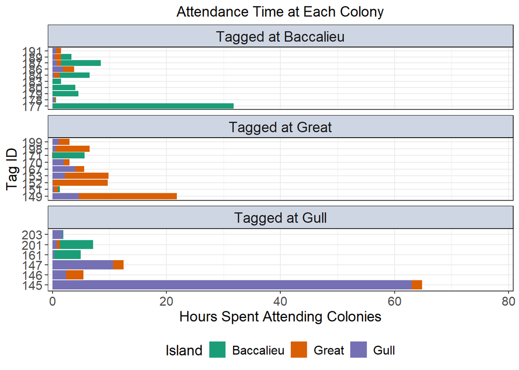

This gives us what I expect for colony attendance time and colony preference. In this figure, very short vacillations between Great and Gull Island don’t make much of a difference, because they only add a minute or two to each colony’s attendance time. However, if we use this dataframe to calculate inter-colony movements:

```
# A tibble: 6 × 3
# Groups:   island [3]
  island    last_island total_movements
  <chr>     <chr>                 <int>
1 Baccalieu Great                     5
2 Baccalieu Gull                      7
3 Great     Baccalieu                 7
4 Great     Gull                    234
5 Gull      Baccalieu                 5
6 Gull      Great                   236
```

### Filtering IC Movements

One simple fix might be to remove all the segments that are only a minute in length from our calculation of inter-colony movements (again, I don’t care so much about removing these from attendance time, because they have such a small effect, though we could always define those one-minute segments as ‘transiting’ and remove them from the colony attendance time as well). This probably takes care of birds that are, for instance, sitting on the Finger, where every once in a while a particularly strong Great Island scan cycle changes their island assignment:

```
# A tibble: 6 × 3
# Groups:   island [3]
  island    last_island total_movements
  <chr>     <chr>                 <int>
1 Baccalieu Great                     1
2 Baccalieu Gull                     11
3 Great     Baccalieu                10
4 Great     Gull                     39
5 Gull      Baccalieu                 1
6 Gull      Great                    48
```

Here is a histogram of all (unfiltered) segment lengths:

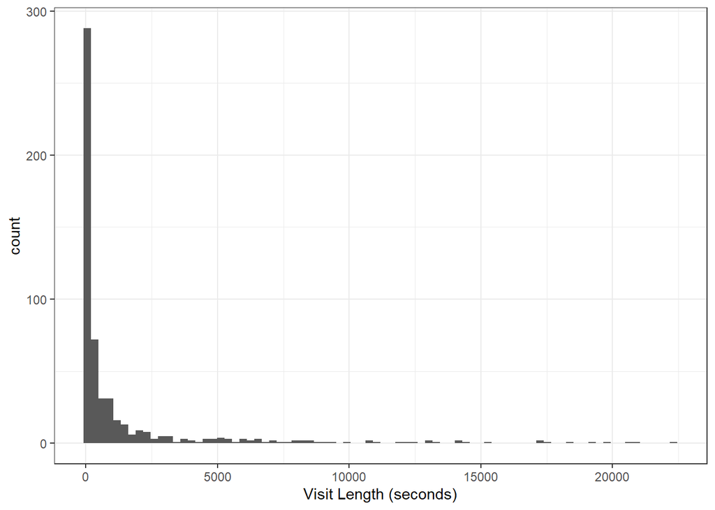

Our longest trips are around 6 hours. If we zoom in on segments less than 15 minutes in length:

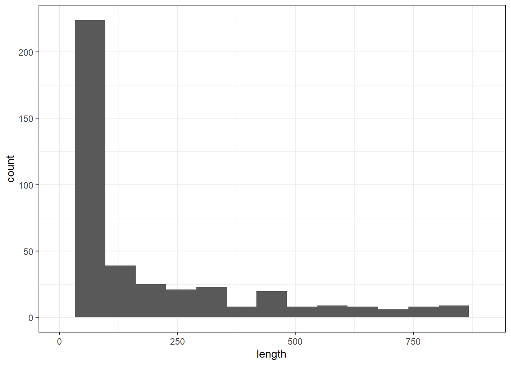

They are predominantly one minute in length, meaning the bird was assigned to a particular island for only one scan cycle. It’s easy to imagine why you might, for instance, get a random Great Island bird-minute assignment in the middle of a bunch of Gull Island assignments: the bird was missed by the Gull Island receiver for a single scan cycle, or one particularly strong transmission came through on the Great Island receiver, etc.

I think this is a fairly effective way of removing rapid vacillations between Great and Gull from our inter-colony movement count while being as generous as possible with colony attendance time. This method is still quite generous with inter-colony movements, because any visit longer than one minute would be counted, there’s no multi-antenna criteria, and it forces birds hanging on in the middle (e.g., on Green Island) to be assigned to one of our islands. For the record, if we also remove those one-minute segments from our colony attendance time, the figure above turns into this:

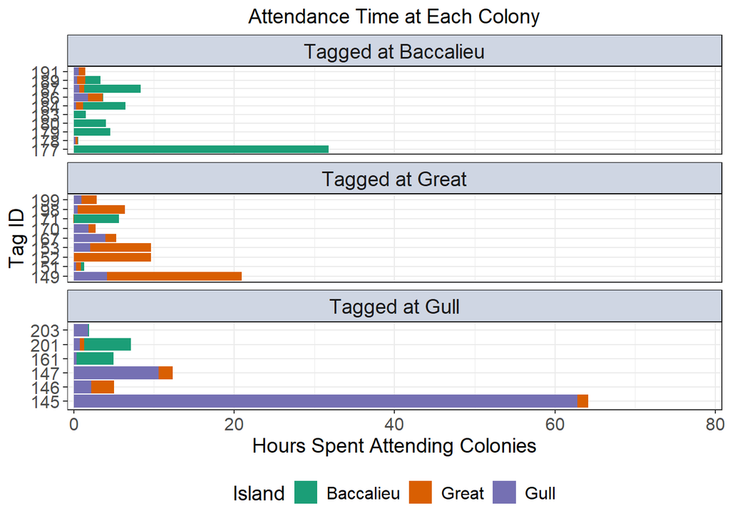

The effect is hardly noticeable.

With the one-minute segments filtered out, our “map” of inter-colony movements (I have been calling these movement ‘pipes’ because of the line/point combination’s appearance) looks familiar:

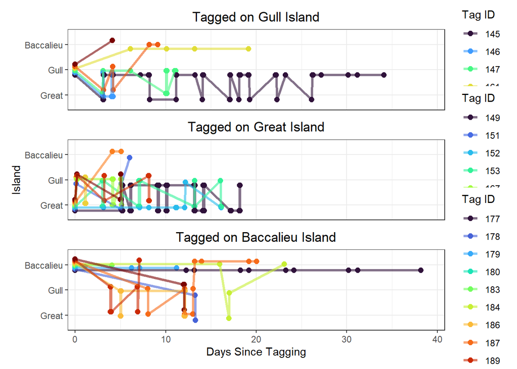

These movement tracks are intelligible but a bit noisy because of all the Gull/Great back and forth.

## Approach Two: Three minute bins, antenna THEN power priority

Here is the exact same code, but our initial binning to create groups of detections assigned to an island uses three minute instead of one minute bins. This should give each receiver more scan attempts per bin to collect information on where the bird is, so it *should* remove rapid vacillations between islands. But it will also increase our attendance time counts, because it will round every period that the bird is present up to at least three minutes.

```r
assigned_to_islands <- prospecting_detections %>%  ## Assign to island based first on number of antennas then based on total power received during a scan cycle
  #filter(nightdate != capture_nightdate) %>%
  mutate(bin = binner(datetime, "3 mins")) %>% #Create five minute-long bins
  group_by(tag_id, bin, island) %>%
  summarize(n_antennas = length(unique(direction)), total_power = mean(power)) %>%
  pivot_wider(names_from = "island", values_from = c("n_antennas", "total_power"), values_fill = 0) %>% #Show number of unique antennas per receiver in each minute
  rename(gull_antennas = n_antennas_Gull,
         great_antennas = n_antennas_Great,
         gull_power = total_power_Gull,
         great_power = total_power_Great,
         bac_antennas = n_antennas_Baccalieu,
         bac_power = total_power_Baccalieu) %>%
  mutate(area = if_else(bac_antennas > 0, "Baccalieu", "Witless Bay")) %>%
  mutate(island = case_when(area == "Witless Bay" & gull_antennas > great_antennas ~ "Gull",
                            area == "Witless Bay" & great_antennas > gull_antennas ~ "Great",
                            area == "Witless Bay" & gull_antennas == great_antennas ~ "Both",
                            area == "Baccalieu" ~ "Baccalieu")) %>%
  mutate(island = case_when(island == "Both" & gull_power > great_power ~ "Gull",
                            island == "Both" & gull_power < great_power ~ "Great",
                            island != "Both" ~ island,
                            .default = NA)) %>%
  filter(!is.na(island))
```

```r
for (i in visitors) { #Create iterating segment numbers

groups = list(1)
counter = 1

df <- assigned_to_islands %>%
  filter(tag_id == i) %>%
  mutate(nightdate = nightdater(bin))

  for (n in 2:length(df$tag_id)) {

    if (df$island[n] == df$island[n-1] & as.character(df$nightdate[n]) == as.character(df$nightdate[n-1])) {
      groups <- append(groups,counter)
     # print("same")
     } else {
      counter = counter + 1
      groups <- append(groups,counter)

      #print("dif")
    }

  }

groups <- as.data.frame(groups)

groups <- groups %>%
  pivot_longer(everything())

df <- cbind(df, groups$value) %>%
  dplyr::rename(segment = `...12`)

visit_segments_loop <- rbind(visit_segments_loop, df)
}
```

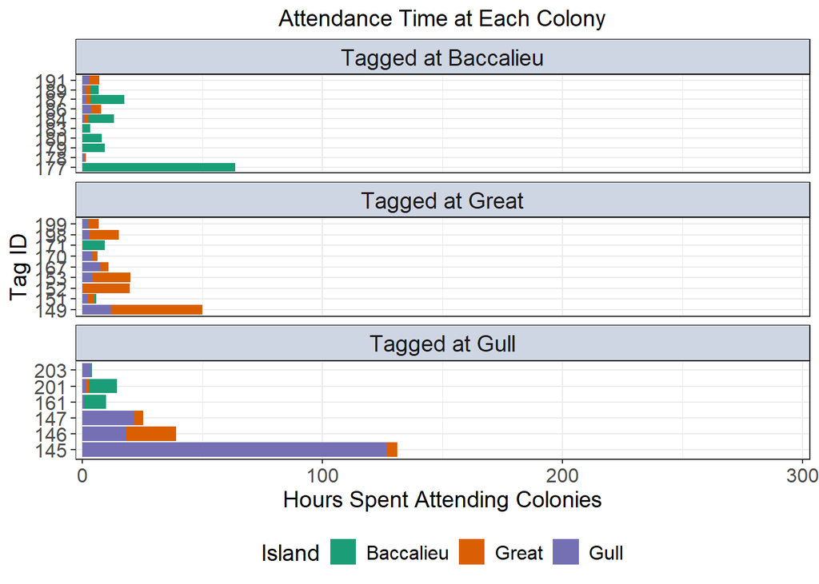

I think this is overly generous with attendance time. It adds extra attendance time in when the birds are moving between the two islands. This method also, for some reason I can’t figure out, dramatically inflates our number of inter-colony movements:

```
# A tibble: 6 × 3
# Groups:   island [3]
  island    last_island total_movements
  <chr>     <chr>                 <int>
1 Baccalieu Great                    10
2 Baccalieu Gull                     12
3 Great     Baccalieu                10
4 Great     Gull                    349
5 Gull      Baccalieu                11
6 Gull      Great                   349
```

There’s no way this dataset should include more than 700 inter-colony movements. If we filter out the standalone segments that are only three minutes in length, attendance time is affected somewhat:

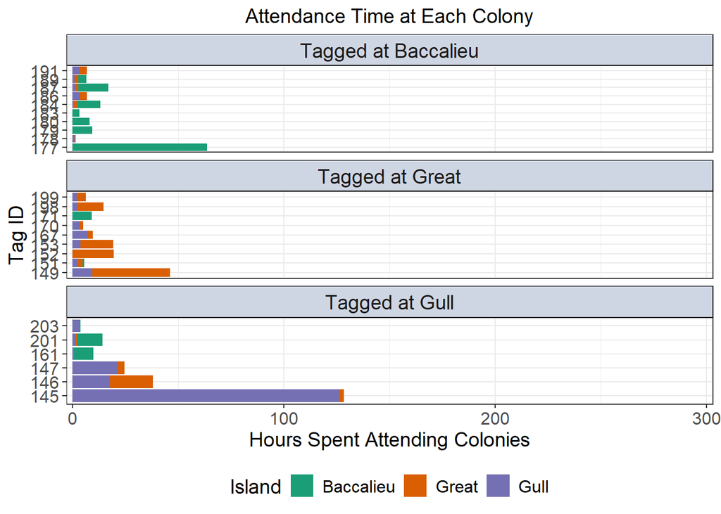

And the count of inter-colony movements is much improved:

```
# A tibble: 5 × 3
# Groups:   island [3]
  island    last_island total_movements
  <chr>     <chr>                 <int>
1 Baccalieu Gull                     11
2 Great     Baccalieu                 8
3 Great     Gull                     32
4 Gull      Baccalieu                 2
5 Gull      Great                    40
```

Again, we can see from a histogram that most of the short segments are as short as it is possible to be (three minutes), so it probably makes sense to filter those out:

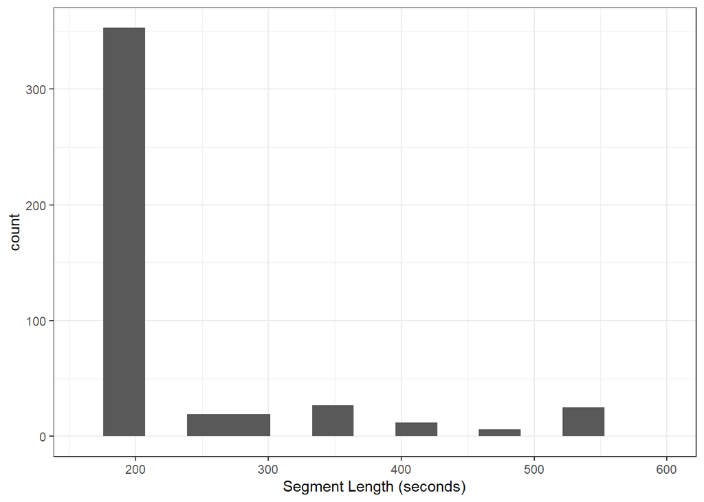

Here is what the movement pipes look like with three-minute bins, where the shortest segments are filtered out:

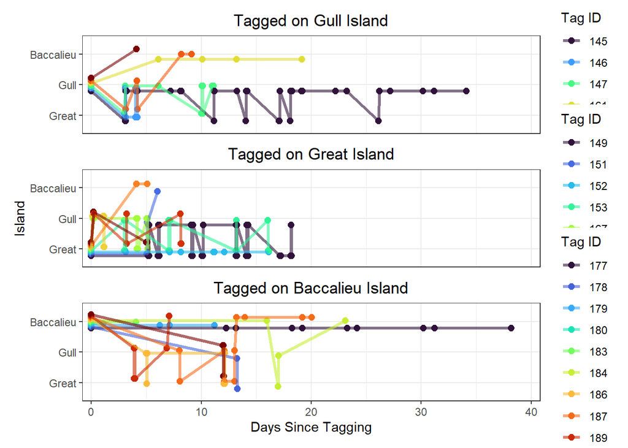

## Approach 3: More conservative antenna criteria

One option would be to include only one-minute bins where a bird is detected on two or more antennas per receiver, but to calculate segments the same way (runs of bins where the night-of date and the assigned island stay the same). This will cause time spent in between the two islands to be assigned to the most recent island where the bird pinged two antennas.

We’ll still start by assigning birds to islands on a one bird-minute basis, still using antenna number as our first priority and signal strength as a second priority.

If we then filter out any bins where fewer than two antennas per receiver were pinged, segments will only start when >1 antenna is pinged. But the last detection in each segment (and therefore the end of the segment) will also be the last bin where two antennas per receiver were pinged. This will remove a lot of “transit” time from our attendance time.

Despite our antenna filtering, a lot of segments are still only a minute in length:

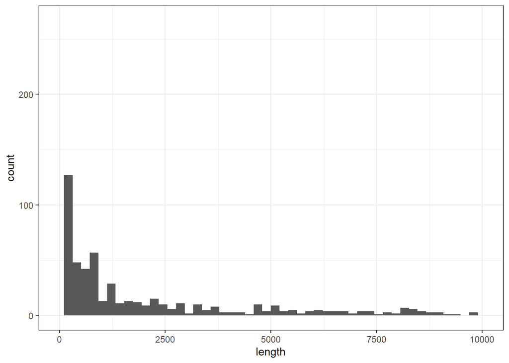

I went ahead and filtered out those bins that are only one minute in length, since they unnecessarily inflate our inter-colony movement count.

This ends up being pretty generous for attendance time, since it assigns a lot transit time to a prior island.

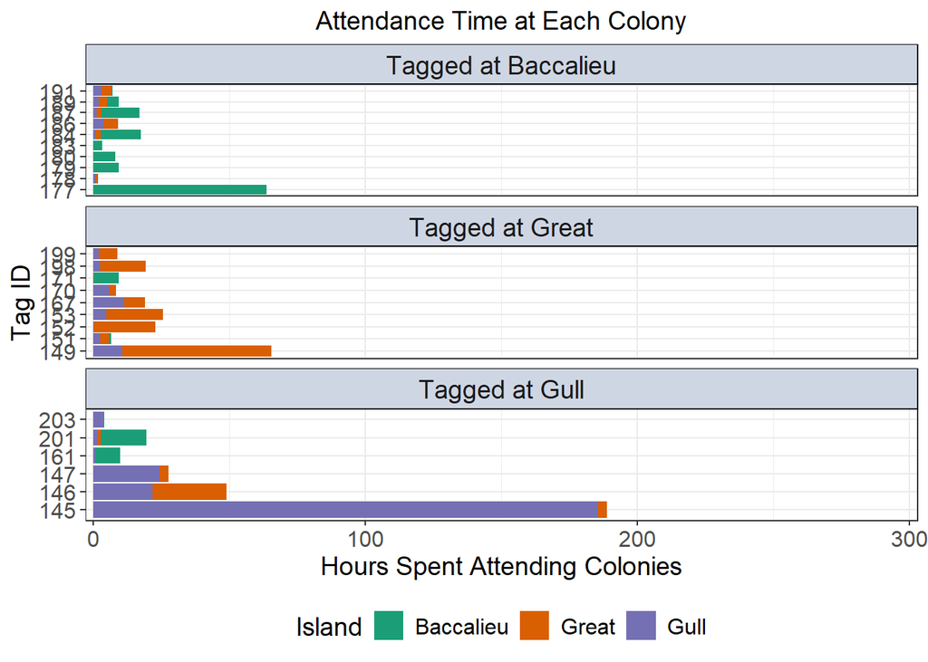

And it gives about what we expect for inter-colony movements:

```
# A tibble: 6 × 3
# Groups:   island [3]
  island    last_island total_movements
  <chr>     <chr>                 <int>
1 Baccalieu Great                     1
2 Baccalieu Gull                     11
3 Great     Baccalieu                10
4 Great     Gull                     39
5 Gull      Baccalieu                 1
6 Gull      Great                    48
```

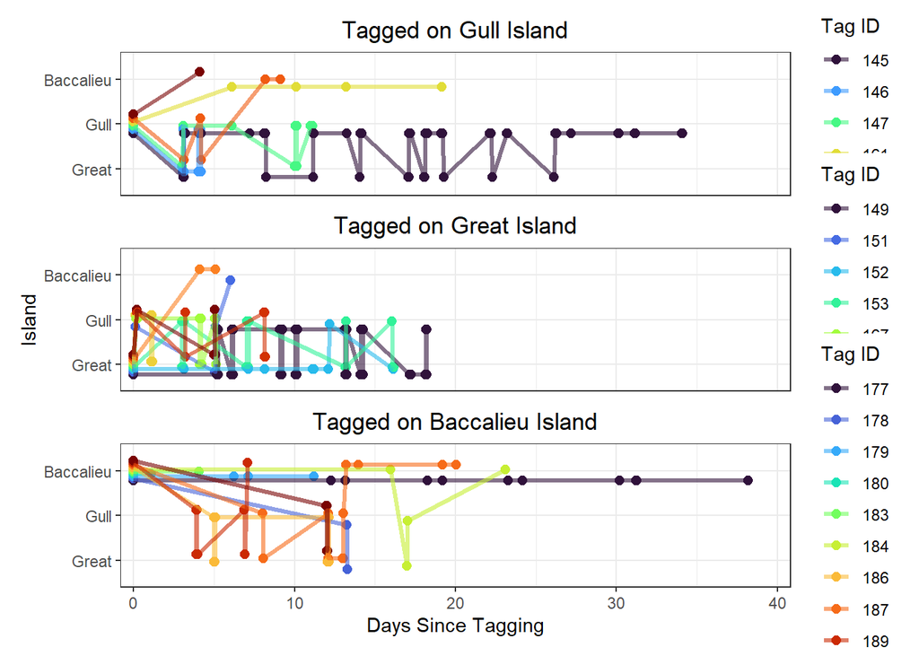

I can try different methods with antenna criteria. I’m actually surprised by how little the more conservative antenna criteria changes things; I guess it is very common for birds to ping multiple antennas.

For now I think I prefer either the first strategy with one-minute bins or this last strategy with a two-antenna critera, but this last one is probably harder to write up/justify.